# Exploratory analysis: Formal limits

*Summary*: The formal limits dimension is probably the least problematic of our dimensions.

The Formal limits scale in the summaries below has been constructed on the basis of these items:

- 35 Does the proposal have to be submitted as a (draft) legal text?
- 37 Is there a clarity of the question requirement?
- 38 Is there a unity of form requirement?
- 39 Is there a unity of substance requirement?

*Important Note:* for the Law-initiated, item 35 was not used.

A quick glimpse at the distribution of Answers (Yes vs No) per item suggests that most items elicited a good number of “Yes” responses.

| Answer | 35 | 37 | 38 | 39 |
| --- | --- | --- | --- | --- |
| No | 72 | 85 | 131 | 108 |
| Yes | 40 | 54 | 8 | 31 |

The one potentially problematic cell is related to item 38 (unity of form). This is a very rare requirement. It is only relevant in 4 countries as shown in table below

| Country | Instrument |
| --- | --- |
| Italy | Rejective initiative |
| Italy | Subnational-initiated |
| Liechtenstein | Proactive initiative |
| Liechtenstein | Rejective initiative |
| Liechtenstein | Subnational-initiated |
| Lithuania | Legislature-initiated |
| Lithuania | Proactive initiative |
| Switzerland | Proactive initiative |

Leaving aside any issues related to item 38 for the time being, the analytical summaries below contain 2 types of summary for the Formal limits, a) a graphical summary and b) table summaries with all the cases per instrument (see Annex for detailed country/item/instrument lists).

# Graphical Data Summary

### Formal limits scale

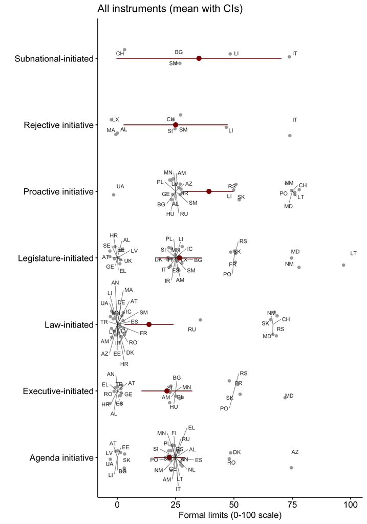

[output not shown]

### Breakdwon per country/instrument

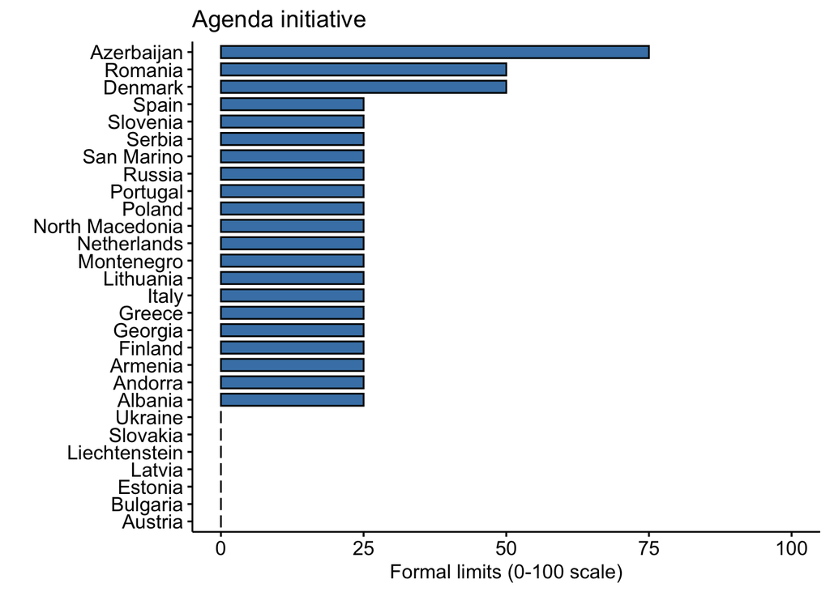

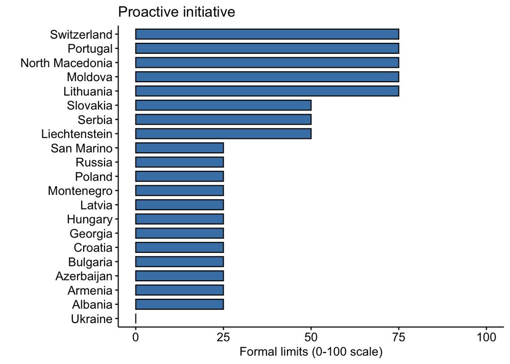

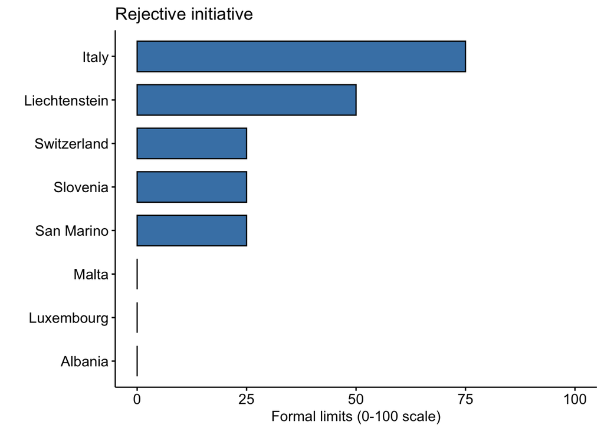

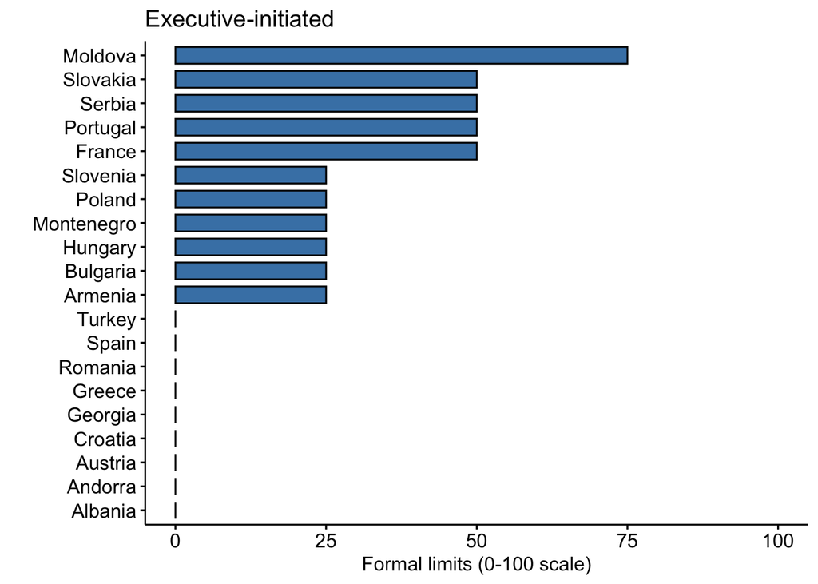

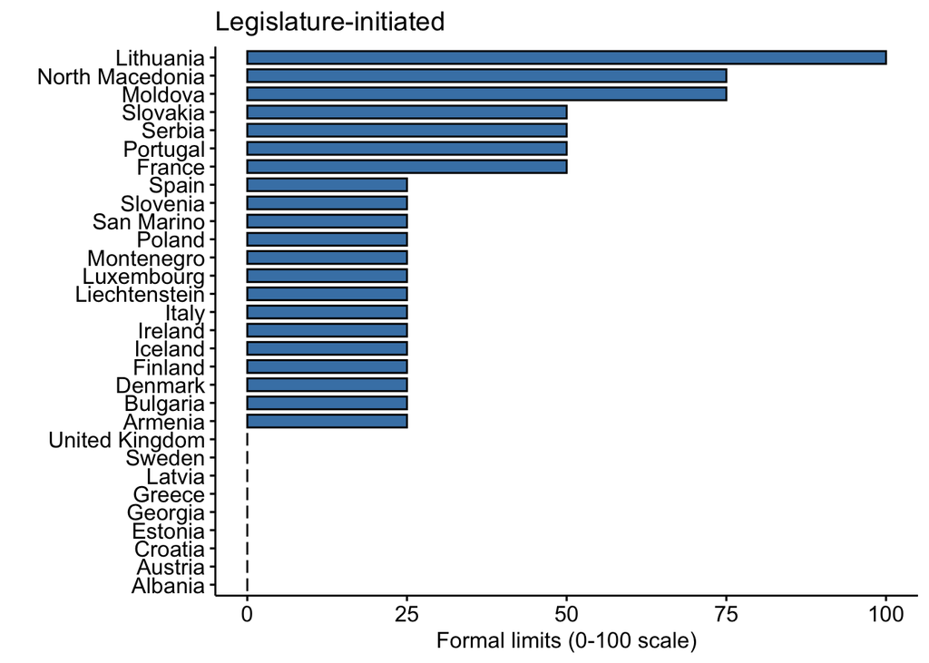

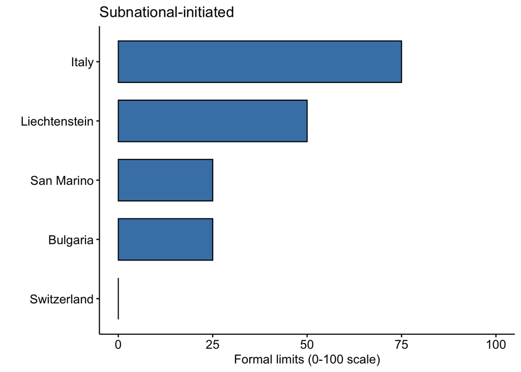

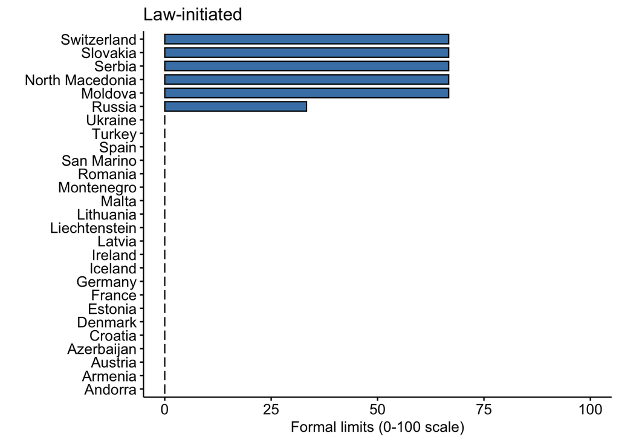

# ANNEX

## Country results by instrument

# Executive-Initiated

### 0) Draft legal text

| Answer | Country |
| --- | --- |
| No | Albania |
| No | Andorra |
| No | Armenia |
| No | Austria |
| No | Bulgaria |
| No | Croatia |
| No | Georgia |
| No | Greece |
| No | Hungary |
| No | Poland |
| No | Portugal |
| No | Romania |
| No | Serbia |
| No | Slovakia |
| No | Slovenia |
| No | Spain |
| No | Turkey |
| Yes | France |
| Yes | Moldova |
| Yes | Montenegro |

### 1) Formal limits on the wording

| Answer | Country |
| --- | --- |
| No | Albania |
| No | Andorra |
| No | Austria |
| No | Croatia |
| No | Georgia |
| No | Greece |
| No | Montenegro |
| No | Romania |
| No | Spain |
| No | Turkey |
| Yes | Armenia |
| Yes | Bulgaria |
| Yes | France |
| Yes | Hungary |
| Yes | Moldova |
| Yes | Poland |
| Yes | Portugal |
| Yes | Serbia |
| Yes | Slovakia |
| Yes | Slovenia |

### 2) Clarity requirement

| Answer | Country |
| --- | --- |
| No | Romania |
| Yes | Armenia |
| Yes | Bulgaria |
| Yes | France |
| Yes | Hungary |
| Yes | Moldova |
| Yes | Poland |
| Yes | Portugal |
| Yes | Serbia |
| Yes | Slovakia |
| Yes | Slovenia |

### 3) Unity of form

| Answer | Country |
| --- | --- |
| No | Armenia |
| No | Bulgaria |
| No | France |
| No | Hungary |
| No | Moldova |
| No | Poland |
| No | Portugal |
| No | Romania |
| No | Serbia |
| No | Slovakia |
| No | Slovenia |

### 4) Unity of substance

| Answer | Country |
| --- | --- |
| No | Armenia |
| No | Bulgaria |
| No | France |
| No | Hungary |
| No | Poland |
| No | Romania |
| No | Slovenia |
| Yes | Moldova |
| Yes | Portugal |
| Yes | Serbia |
| Yes | Slovakia |

### 5) Other formal limits

| Answer | Country |
| --- | --- |
| No | Armenia |
| No | Bulgaria |
| No | France |
| No | Hungary |
| No | Moldova |
| No | Poland |
| No | Romania |
| No | Serbia |
| No | Slovakia |
| No | Slovenia |
| Yes | Portugal |

# Legislature

### 0) Draft legal text

| Answer | Country |
| --- | --- |
| No | Albania |
| No | Armenia |
| No | Austria |
| No | Bulgaria |
| No | Croatia |
| No | Estonia |
| No | Georgia |
| No | Greece |
| No | Iceland |
| No | Latvia |
| No | Poland |
| No | Portugal |
| No | Serbia |
| No | Slovakia |
| No | Slovenia |
| No | Sweden |
| No | United Kingdom |
| Yes | Denmark |
| Yes | Finland |
| Yes | France |
| Yes | Ireland |
| Yes | Italy |
| Yes | Liechtenstein |
| Yes | Lithuania |
| Yes | Luxembourg |
| Yes | Moldova |
| Yes | Montenegro |
| Yes | North Macedonia |
| Yes | San Marino |
| Yes | Spain |

### 1) Formal limits on the wording

| Answer | Country |
| --- | --- |
| No | Albania |
| No | Austria |
| No | Croatia |
| No | Denmark |
| No | Finland |
| No | Georgia |
| No | Greece |
| No | Ireland |
| No | Italy |
| No | Latvia |
| No | Liechtenstein |
| No | Luxembourg |
| No | Montenegro |
| No | San Marino |
| No | Spain |
| No | Sweden |
| No | United Kingdom |
| Yes | Armenia |
| Yes | Bulgaria |
| Yes | Estonia |
| Yes | France |
| Yes | Iceland |
| Yes | Lithuania |
| Yes | Moldova |
| Yes | North Macedonia |
| Yes | Poland |
| Yes | Portugal |
| Yes | Serbia |
| Yes | Slovakia |
| Yes | Slovenia |

### 2) Clarity requirement

| Answer | Country |
| --- | --- |
| No | Estonia |
| Yes | Armenia |
| Yes | Bulgaria |
| Yes | France |
| Yes | Iceland |
| Yes | Lithuania |
| Yes | Moldova |
| Yes | North Macedonia |
| Yes | Poland |
| Yes | Portugal |
| Yes | Serbia |
| Yes | Slovakia |
| Yes | Slovenia |

### 3) Unity of form

| Answer | Country |
| --- | --- |
| No | Armenia |
| No | Bulgaria |
| No | Estonia |
| No | France |
| No | Iceland |
| No | Moldova |
| No | North Macedonia |
| No | Poland |
| No | Portugal |
| No | Serbia |
| No | Slovakia |
| No | Slovenia |
| Yes | Lithuania |

### 4) Unity of substance

| Answer | Country |
| --- | --- |
| No | Armenia |
| No | Bulgaria |
| No | Estonia |
| No | France |
| No | Iceland |
| No | Poland |
| No | Slovenia |
| Yes | Lithuania |
| Yes | Moldova |
| Yes | North Macedonia |
| Yes | Portugal |
| Yes | Serbia |
| Yes | Slovakia |

### 5) Other formal limits

| Answer | Country |
| --- | --- |
| No | Armenia |
| No | Bulgaria |
| No | France |
| No | Iceland |
| No | Lithuania |
| No | Moldova |
| No | North Macedonia |
| No | Poland |
| No | Serbia |
| No | Slovakia |
| No | Slovenia |
| Yes | Estonia |
| Yes | Portugal |

# Subnational

### 0) Draft legal text

| Answer | Country |
| --- | --- |
| No | Bulgaria |
| No | Italy |
| No | Liechtenstein |
| No | San Marino |
| No | Switzerland |

### 1) Formal limits on the wording

| Answer | Country |
| --- | --- |
| No | Switzerland |
| Yes | Bulgaria |
| Yes | Italy |
| Yes | Liechtenstein |
| Yes | San Marino |

### 2) Clarity requirement

| Answer | Country |
| --- | --- |
| No | Liechtenstein |
| Yes | Bulgaria |
| Yes | Italy |
| Yes | San Marino |

### 3) Unity of form

| Answer | Country |
| --- | --- |
| No | Bulgaria |
| No | San Marino |
| Yes | Italy |
| Yes | Liechtenstein |

### 4) Unity of substance

| Answer | Country |
| --- | --- |
| No | Bulgaria |
| No | San Marino |
| Yes | Italy |
| Yes | Liechtenstein |

### 5) Other formal limits

| Answer | Country |
| --- | --- |
| No | Bulgaria |
| No | Italy |
| No | Liechtenstein |
| No | San Marino |

# Rejective initiative

### 0) Draft legal text

| Answer | Country |
| --- | --- |
| No | Albania |
| No | Italy |
| No | Liechtenstein |
| No | Luxembourg |
| No | Malta |
| No | San Marino |
| No | Switzerland |
| Yes | Slovenia |

### 1) Formal limits on the wording

| Answer | Country |
| --- | --- |
| No | Albania |
| No | Luxembourg |
| No | Malta |
| Yes | Italy |
| Yes | Liechtenstein |
| Yes | San Marino |
| Yes | Slovenia |
| Yes | Switzerland |

### 2) Clarity requirement

| Answer | Country |
| --- | --- |
| No | Liechtenstein |
| No | Slovenia |
| No | Switzerland |
| Yes | Italy |
| Yes | San Marino |

### 3) Unity of form

| Answer | Country |
| --- | --- |
| No | San Marino |
| No | Slovenia |
| No | Switzerland |
| Yes | Italy |
| Yes | Liechtenstein |

### 4) Unity of substance

| Answer | Country |
| --- | --- |
| No | San Marino |
| No | Slovenia |
| Yes | Italy |
| Yes | Liechtenstein |
| Yes | Switzerland |

### 5) Other formal limits

| Answer | Country |
| --- | --- |
| No | Italy |
| No | Liechtenstein |
| No | San Marino |
| No | Switzerland |
| Yes | Slovenia |

# Proactive initiative

### 0) Draft legal text

| Answer | Country |
| --- | --- |
| No | Albania |
| No | Armenia |
| No | Bulgaria |
| No | Croatia |
| No | Hungary |
| No | Liechtenstein |
| No | Lithuania |
| No | Poland |
| No | Russia |
| No | San Marino |
| No | Serbia |
| No | Slovakia |
| No | Switzerland |
| No | Ukraine |
| Yes | Azerbaijan |
| Yes | Georgia |
| Yes | Latvia |
| Yes | Moldova |
| Yes | Montenegro |
| Yes | North Macedonia |
| Yes | Portugal |

### 1) Formal limits on the wording

| Answer | Country |
| --- | --- |
| No | Azerbaijan |
| No | Georgia |
| No | Latvia |
| No | Montenegro |
| No | Ukraine |
| Yes | Albania |
| Yes | Armenia |
| Yes | Bulgaria |
| Yes | Croatia |
| Yes | Hungary |
| Yes | Liechtenstein |
| Yes | Lithuania |
| Yes | Moldova |
| Yes | North Macedonia |
| Yes | Poland |
| Yes | Portugal |
| Yes | Russia |
| Yes | San Marino |
| Yes | Serbia |
| Yes | Slovakia |
| Yes | Switzerland |

### 2) Clarity requirement

| Answer | Country |
| --- | --- |
| No | Liechtenstein |
| Yes | Albania |
| Yes | Armenia |
| Yes | Bulgaria |
| Yes | Croatia |
| Yes | Hungary |
| Yes | Lithuania |
| Yes | Moldova |
| Yes | North Macedonia |
| Yes | Poland |
| Yes | Portugal |
| Yes | Russia |
| Yes | San Marino |
| Yes | Serbia |
| Yes | Slovakia |
| Yes | Switzerland |

### 3) Unity of form

| Answer | Country |
| --- | --- |
| No | Albania |
| No | Armenia |
| No | Bulgaria |
| No | Croatia |
| No | Hungary |
| No | Moldova |
| No | North Macedonia |
| No | Poland |
| No | Portugal |
| No | Russia |
| No | San Marino |
| No | Serbia |
| No | Slovakia |
| Yes | Liechtenstein |
| Yes | Lithuania |
| Yes | Switzerland |

### 4) Unity of substance

| Answer | Country |
| --- | --- |
| No | Albania |
| No | Armenia |
| No | Bulgaria |
| No | Croatia |
| No | Hungary |
| No | Poland |
| No | Russia |
| No | San Marino |
| Yes | Liechtenstein |
| Yes | Lithuania |
| Yes | Moldova |
| Yes | North Macedonia |
| Yes | Portugal |
| Yes | Serbia |
| Yes | Slovakia |
| Yes | Switzerland |

### 5) Other formal limits

| Answer | Country |
| --- | --- |
| No | Albania |
| No | Armenia |
| No | Bulgaria |
| No | Croatia |
| No | Hungary |
| No | Liechtenstein |
| No | Lithuania |
| No | Moldova |
| No | North Macedonia |
| No | Poland |
| No | Russia |
| No | San Marino |
| No | Serbia |
| No | Slovakia |
| No | Switzerland |
| Yes | Portugal |

# Agenda initiative

### 0) Draft legal text

| Answer | Country |
| --- | --- |
| No | Austria |
| No | Bulgaria |
| No | Denmark |
| No | Estonia |
| No | Finland |
| No | Latvia |
| No | Liechtenstein |
| No | Netherlands |
| No | Russia |
| No | Serbia |
| No | Slovakia |
| No | Ukraine |
| Yes | Albania |
| Yes | Andorra |
| Yes | Armenia |
| Yes | Azerbaijan |
| Yes | Georgia |
| Yes | Greece |
| Yes | Italy |
| Yes | Lithuania |
| Yes | Montenegro |
| Yes | North Macedonia |
| Yes | Poland |
| Yes | Portugal |
| Yes | Romania |
| Yes | San Marino |
| Yes | Slovenia |
| Yes | Spain |

### 1) Formal limits on the wording

| Answer | Country |
| --- | --- |
| No | Albania |
| No | Andorra |
| No | Armenia |
| No | Bulgaria |
| No | Estonia |
| No | Georgia |
| No | Greece |
| No | Latvia |
| No | Liechtenstein |
| No | Lithuania |
| No | Montenegro |
| No | Poland |
| No | Portugal |
| No | San Marino |
| No | Slovakia |
| No | Spain |
| No | Ukraine |
| Yes | Austria |
| Yes | Azerbaijan |
| Yes | Denmark |
| Yes | Finland |
| Yes | Italy |
| Yes | Netherlands |
| Yes | North Macedonia |
| Yes | Romania |
| Yes | Russia |
| Yes | Serbia |
| Yes | Slovenia |

### 2) Clarity requirement

| Answer | Country |
| --- | --- |
| No | Austria |
| No | Estonia |
| No | Finland |
| No | North Macedonia |
| No | Slovenia |
| Yes | Azerbaijan |
| Yes | Denmark |
| Yes | Netherlands |
| Yes | Romania |
| Yes | Russia |
| Yes | Serbia |

### 3) Unity of form

| Answer | Country |
| --- | --- |
| No | Austria |
| No | Azerbaijan |
| No | Denmark |
| No | Estonia |
| No | Finland |
| No | Netherlands |
| No | North Macedonia |
| No | Romania |
| No | Russia |
| No | Serbia |
| No | Slovenia |

### 4) Unity of substance

| Answer | Country |
| --- | --- |
| No | Austria |
| No | Estonia |
| No | Netherlands |
| No | North Macedonia |
| No | Romania |
| No | Russia |
| No | Serbia |
| No | Slovenia |
| Yes | Azerbaijan |
| Yes | Denmark |
| Yes | Finland |

### 5) Other formal limits

| Answer | Country |
| --- | --- |
| No | Azerbaijan |
| No | Denmark |
| No | Estonia |
| No | Netherlands |
| No | Romania |
| No | Russia |
| No | Serbia |
| Yes | Austria |
| Yes | Finland |
| Yes | Italy |
| Yes | North Macedonia |
| Yes | Portugal |
| Yes | Slovenia |

# Law-initiated

### 0) Draft legal text

(NOT APPLICABLE)

### 1) Formal limits on the wording

| Answer | Country |
| --- | --- |
| No | Andorra |
| No | Armenia |
| No | Austria |
| No | Croatia |
| No | Denmark |
| No | France |
| No | Germany |
| No | Iceland |
| No | Ireland |
| No | Latvia |
| No | Liechtenstein |
| No | Lithuania |
| No | Malta |
| No | Montenegro |
| No | San Marino |
| No | Spain |
| No | Turkey |
| No | Ukraine |
| Yes | Azerbaijan |
| Yes | Estonia |
| Yes | Moldova |
| Yes | North Macedonia |
| Yes | Romania |
| Yes | Russia |
| Yes | Serbia |
| Yes | Slovakia |
| Yes | Switzerland |

### 2) Clarity requirement

| Answer | Country |
| --- | --- |
| No | Azerbaijan |
| No | Estonia |
| No | Romania |
| Yes | Moldova |
| Yes | North Macedonia |
| Yes | Russia |
| Yes | Serbia |
| Yes | Slovakia |
| Yes | Switzerland |

### 3) Unity of form

| Answer | Country |
| --- | --- |
| No | Azerbaijan |
| No | Estonia |
| No | Moldova |
| No | North Macedonia |
| No | Romania |
| No | Russia |
| No | Serbia |
| No | Slovakia |
| No | Switzerland |

### 4) Unity of substance

| Answer | Country |
| --- | --- |
| No | Azerbaijan |
| No | Estonia |
| No | Romania |
| No | Russia |
| Yes | Moldova |
| Yes | North Macedonia |
| Yes | Serbia |
| Yes | Slovakia |
| Yes | Switzerland |

### 5) Other formal limits

| Answer | Country |
| --- | --- |
| No | Moldova |
| No | North Macedonia |
| No | Russia |
| No | Serbia |
| No | Slovakia |
| No | Switzerland |
| Yes | Azerbaijan |
| Yes | Estonia |
| Yes | Romania |